# Nutrient Solubility

Comparison of empirical nutrient concentrations with theoretical solubilities

Anıl A. Tellbüscher

2022-06-26

```r
library(tidyverse)
library(XLConnect)
```

# General

- Comparison of empirical nutrient concentrations in the aquaculture or remineralisation unit with theoretical solubilities of some salts and recommended concentrations from hydroponic literature
- All concentrations need to be corrected
  - Values for PO4 are representing c_total, so they must be converted into [PO4 3-] to assess whether values are indeed above maximum solubility

# 1. Nutrient solubility data

After excluding nutrients that have a highly variable input, the next questions are

1. if the inclusion of one or multiple of the remaining nutrients would actually lead to an increase of their free concentration
2. whether or not the inclusion of these nutrients might cause interactions with other nutrients such as precipitation

## Load data

```r
nutrientSolubility <- read.csv('data/solubilityCalculated.csv')
```

## Convert dataset

### Create cation solubility dataset

```r
# Preparation of solubility data
cationSolubility <- nutrientSolubility %>%
  filter(X != "Iron(III) hydroxide" & chemAnion != "S") %>%
  select(-c('X', 'chemFormula')) %>%
  arrange('solSaltmg') %>%
  group_by(chemCation) %>%
  summarise(minSolubility = min(solCationmg)) %>%
  rename("nutrient" = "chemCation") %>%
  arrange(minSolubility) %>%
  print()
```

```
## # A tibble: 10 × 2
##    nutrient minSolubility
##    <chr>            <dbl>
##  1 Fe              0.0018
##  2 Cu              0.0032
##  3 Zn              0.03
##  4 Ni              0.038
##  5 Mn              0.26
##  6 Ca              0.3
##  7 Mg              0.46
##  8 B           10000
##  9 K           54000
## 10 NH4         63000
```

### Create anion solubility dataset

```r
anionSolubility <- nutrientSolubility %>%
  filter(X != "Iron(III) hydroxide" & chemAnion != "S") %>%
  select(-c('X', 'chemFormula')) %>%
  arrange('solSaltmg') %>%
  group_by(chemAnion) %>%
  summarise(minSolubility = min(solAnionmg)) %>%
  rename("nutrient" = "chemAnion") %>%
  arrange(minSolubility) %>%
  print()
```

```
## # A tibble: 10 × 2
##    nutrient minSolubility
##    <chr>            <dbl>
##  1 PO4              0.003
##  2 OH               0.067
##  3 CO3              0.28
##  4 SO4            540
##  5 SO3            990
##  6 Cl          170000
##  7 H2PO4       180000
##  8 HCO3        220000
##  9 NO3         230000
## 10 HPO4        500000
```

### Create dataset that contains lowest mass solubility for all the compounds

```r
lowSolubility <- cationSolubility %>%
  bind_rows(anionSolubility) %>%
  mutate(
    # Conversion of nutrient into factor
    nutrient = factor(nutrient,
                            levels = c('Fe', 'Cu', 'Ca', 'Ni', 'Zn', 'Mn', 'Mg', 'B', 'K', 'NH4', 'PO4', 'OH', 'CO3', 'SO4', 'SO3', 'H2PO4', 'HCO3', 'NO3', 'Cl', 'HPO4'),
                            labels = c('Fe', 'Cu', 'Ca', 'Ni', 'Zn', 'Mn', 'Mg', 'B', 'K', 'N', 'P', 'OH', 'CO3', 'S', 'SO3', 'H2PO4', 'HCO3', 'NO3', 'Cl', 'HPO4'))) %>%
  print()
```

```
## # A tibble: 20 × 2
##    nutrient minSolubility
##    <fct>            <dbl>
##  1 Fe              0.0018
##  2 Cu              0.0032
##  3 Zn              0.03
##  4 Ni              0.038
##  5 Mn              0.26
##  6 Ca              0.3
##  7 Mg              0.46
##  8 B           10000
##  9 K           54000
## 10 N           63000
## 11 P               0.003
## 12 OH              0.067
## 13 CO3             0.28
## 14 S             540
## 15 SO3           990
## 16 Cl         170000
## 17 H2PO4      180000
## 18 HCO3       220000
## 19 NO3        230000
## 20 HPO4       500000
```

# 2. Target concentrations

## Load data

```r
resh_hydroponic_plant_production <- loadWorkbook(filename = "data/Resh - Hydroponic Plant Production.xlsx")
resh <- readWorksheet(resh_hydroponic_plant_production, sheet = "nutrient solutions", region = c('A', 'C2:Q50'))

resh <- data.frame(resh[[2]], row.names = resh[[1]][2:49,1])
```

## Convert dataset

```r
targetConc <- resh %>%
  rename('P' = 'PO4_P_mgL', 'K' = 'K_mgL', 'Ca' = 'Ca_mgL', 'Mg' = 'Mg_mgL', 'S' = 'SO4_S_mgL', 'B' = 'B_mgL', 'Fe' = 'Fe_mgL', 'Mn' = 'Mn_mgL', 'Cu' = 'Cu_mgL', 'Zn' = 'Zn_mgL', 'Na' = 'Na_mgL', 'NH4' = 'NH4_N_mgL', 'Mo' = 'Mo_mgL', 'NO3' = 'NO3_N_mgL', 'Cl' = 'Cl_mgL') %>%

  # Calculate total N
  mutate(
    N = NH4 + NO3
  ) %>%
  select(-c('NH4', 'NO3')) %>%

  # Create longtable
  pivot_longer(
    everything(),
    names_to = 'nutrient',
    values_to = 'concentration'
    ) %>%

  # Remove missing values
  drop_na() %>%
  group_by(nutrient) %>%
  summarise(mean = mean(concentration)) %>%
  arrange(desc(mean))
```

## Convert units

```r
# Load data
molarWeight <- read.csv2('data/molarWeight.csv')
molarWeight$g_per_mol <- as.numeric(molarWeight$g_per_mol)


targetConc %>%
  # Add molar weight dataset
  left_join(molarWeight, by = c('nutrient' = 'element')) %>%

  # Convert mmol/L into mg/L
  mutate(
    concentration = mean * g_per_mol
    ) %>%
  select(-c('mean', 'g_per_mol'))
```

```
## # A tibble: 14 × 2
##    nutrient concentration
##    <chr>            <dbl>
##  1 K             10308.
##  2 Ca             7677.
##  3 N              2679.
##  4 S              4135.
##  5 Cl             2519.
##  6 P              1880.
##  7 Mg             1468.
##  8 Na             1184.
##  9 Fe              143.
## 10 Mn               29.8
## 11 B                 4.35
## 12 Zn               12.6
## 13 Mo               11.0
## 14 Cu                3.72
```

# 3. Empirical data

Only data from on-demand coupled aquaponic systems or supernatants from remineralisation tanks is used. This is because the data shall not be impacted by plant uptake of nutrients. Instead, it is intended to visualize a satiation concentration that should be reached over time.

## Load data

```r
# Load data
masterfile_nutrients <- loadWorkbook(filename = "data/Aquaponics - Masterfile Nutrients.xlsx")
empirical_data <- readWorksheet(masterfile_nutrients, sheet = 'waterAVERAGE')
```

## Add nutrient classification

```r
# Load data
classes <- read.csv2('data/nutrientClassification.csv')

plotdata <- plotdata %>%
  left_join(classes, by = c('nutrient' = 'nutrient'))
```

## Write data for further analysis

```r
write.csv(plotdata, file = 'data/empirical_data.csv')
```

## Remove unnecessary data from minimum solubility dataset

```r
lowSolubility <- lowSolubility[which(lowSolubility$nutrient %in% plotdata$nutrient),]
droplevels(lowSolubility$nutrient)
```

```
##  [1] Fe Cu Zn Mn Ca Mg B  K  N  P  S
## Levels: Fe Cu Ca Zn Mn Mg B K N P S
```

## Plot data

### Total Plot

The plot is created using empirical data. Concentrations of plant nutrients are plotted against the sampling day. The data is further classified according to the unit where the sample for analysis was drawn from (is it water from an aquaculture unit or supernatant from a remineralisation system?)

Black dashed lines are indicating the theoretical solubility if it was depending on the salt with the lowest solubility in the system, while the red dashed lines indicate the average target concentrations suggested by Resh.

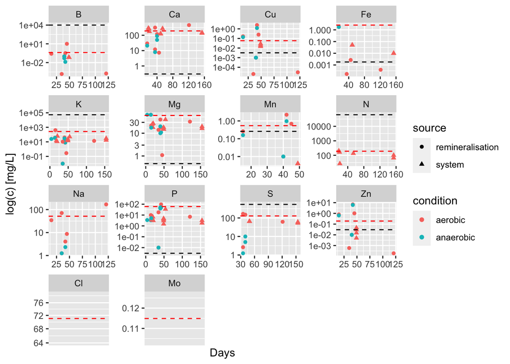

```r
plotdata %>%
  ggplot(aes(x = days, y = concentration, colour = condition, shape = source)) +
  geom_point() +
  geom_hline(data = lowSolubility, aes(yintercept = minSolubility), linetype = 'dashed') +
  geom_hline(data = targetConc, aes(yintercept = mean), linetype = 'dashed', color = 'red') +
  facet_wrap(facets = vars(as.factor(nutrient)), scales = 'free') +
  scale_y_log10() +
  labs(
    x = 'Days',
    y = 'log(c) [mg/L]'
    )
```

**In the next step, a pH-correction of the theoretical solubility threshold based on empirical data will be done, see RMarkdown file 3-NutrientSolubility-pH-corrected.**

## Group plots

### Macronutrients

Black dashed lines are indicating the theoretical solubility if it was depending on the salt with the lowest solubility in the system, while the red dashed lines indicate the average target concentrations suggested by Resh.

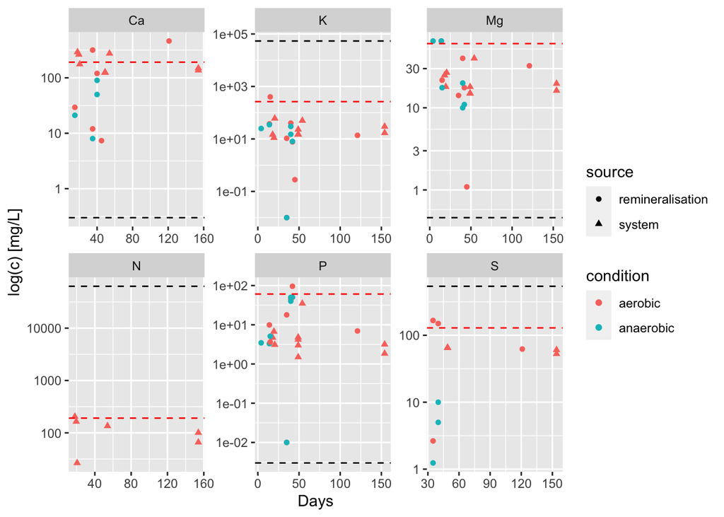

```r
plotlevels <- unlist(unique(subset(plotdata, group3 == 'macronutrient', select = nutrient)))

plotdata %>%
  filter(group3 == 'macronutrient') %>%
  ggplot(aes(x = days, y = concentration, colour = condition, shape = source)) +
  geom_point() +
  geom_hline(data = lowSolubility[which(lowSolubility$nutrient %in% plotlevels),], aes(yintercept = minSolubility), linetype = 'dashed') +
  geom_hline(data = targetConc[which(targetConc$nutrient %in% plotlevels),], aes(yintercept = mean), linetype = 'dashed', color = 'red') +
  facet_wrap(facets = vars(as.factor(nutrient)), scales = 'free') +
  scale_y_log10() +
  labs(
    x = 'Days',
    y = 'log(c) [mg/L]'
    )
```

### Microminerals

Black dashed lines are indicating the theoretical solubility if it was depending on the salt with the lowest solubility in the system, while the red dashed lines indicate the average target concentrations suggested by Resh.

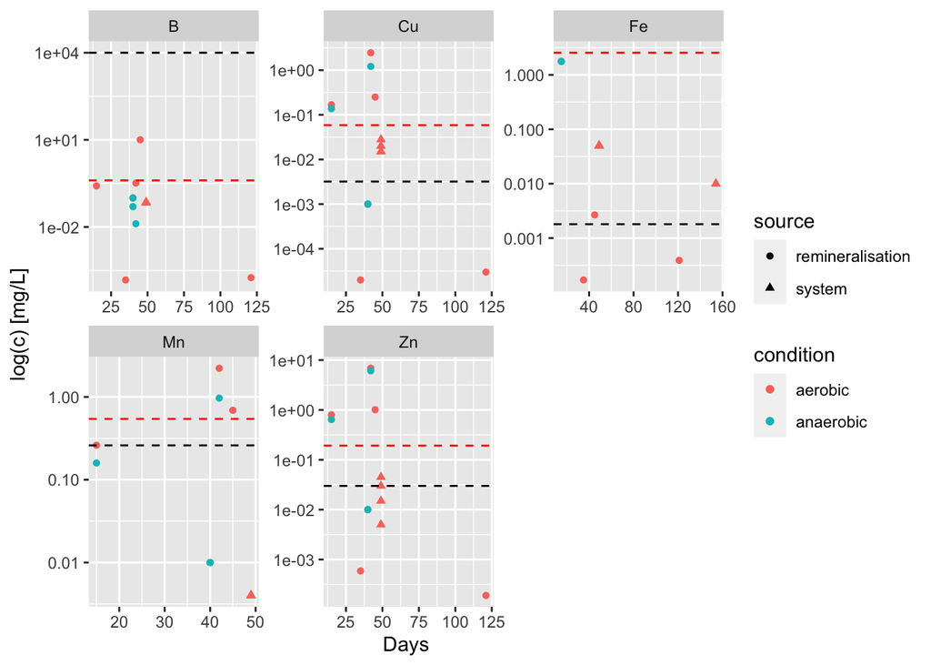

```r
plotlevels <- unlist(unique(subset(plotdata, group3 == 'micronutrient', select = nutrient)))

plotdata %>%
  filter(group3 == 'micronutrient') %>%

  ggplot(aes(x = days, y = concentration, colour = condition, shape = source)) +

  geom_point() +

  geom_hline(data = lowSolubility[which(lowSolubility$nutrient %in% plotlevels),], aes(yintercept = minSolubility), linetype = 'dashed') +

  geom_hline(data = targetConc[which(targetConc$nutrient %in% plotlevels),], aes(yintercept = mean), linetype = 'dashed', color = 'red') +

  facet_wrap(facets = vars(as.factor(nutrient)), scales = 'free') +

  scale_y_log10() +

  labs(
    x = 'Days',
    y = 'log(c) [mg/L]'
    )
```

### Group 1

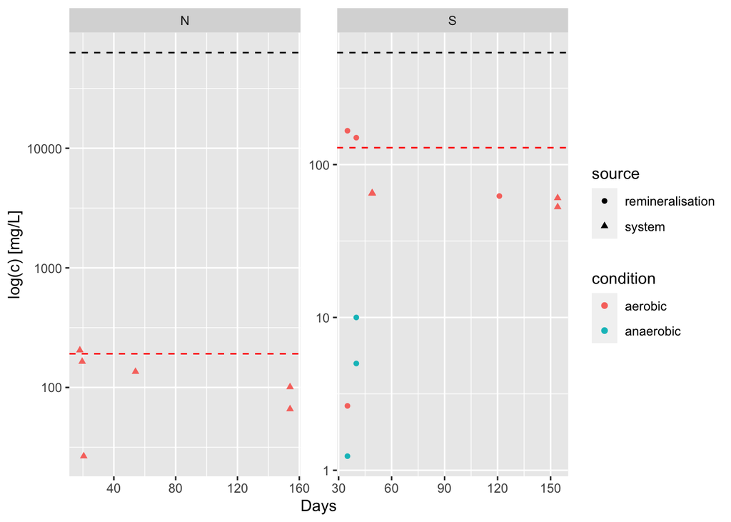

```r
plotlevels <- unlist(unique(subset(plotdata, group1 == 1, select = nutrient)))

plotdata %>%
  filter(group1 == 1) %>%
  ggplot(aes(x = days, y = concentration, colour = condition, shape = source)) +
  geom_point() +
  geom_hline(data = lowSolubility[which(lowSolubility$nutrient %in% plotlevels),], aes(yintercept = minSolubility), linetype = 'dashed') +
  geom_hline(data = targetConc[which(targetConc$nutrient %in% plotlevels),], aes(yintercept = mean), linetype = 'dashed', color = 'red') +
  facet_wrap(facets = vars(as.factor(nutrient)), scales = 'free') +
  scale_y_log10() +
  labs(
    x = 'Days',
    y = 'log(c) [mg/L]'
    )
```

### Group 2

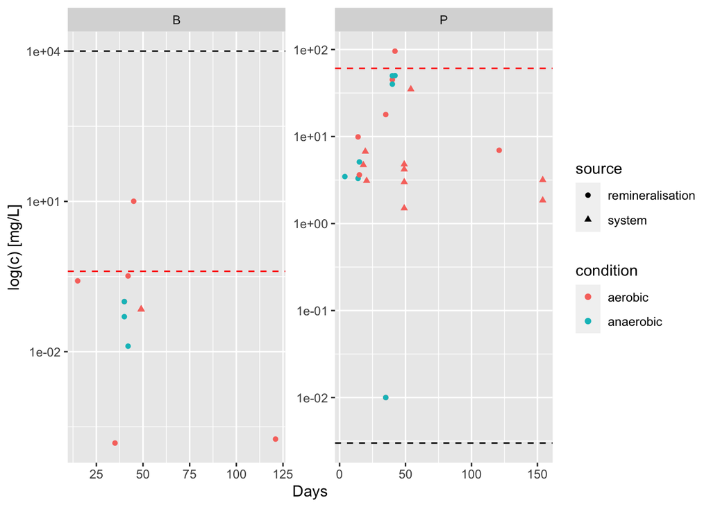

```r
plotlevels <- unlist(unique(subset(plotdata, group1 == 2, select = nutrient)))

plotdata %>%
  filter(group1 == 2) %>%
  ggplot(aes(x = days, y = concentration, colour = condition, shape = source)) +
  geom_point() +
  geom_hline(data = lowSolubility[which(lowSolubility$nutrient %in% plotlevels),], aes(yintercept = minSolubility), linetype = 'dashed') +
  geom_hline(data = targetConc[which(targetConc$nutrient %in% plotlevels),], aes(yintercept = mean), linetype = 'dashed', color = 'red') +
  facet_wrap(facets = vars(as.factor(nutrient)), scales = 'free') +
  scale_y_log10() +
  labs(
    x = 'Days',
    y = 'log(c) [mg/L]'
    )
```

### Group 3

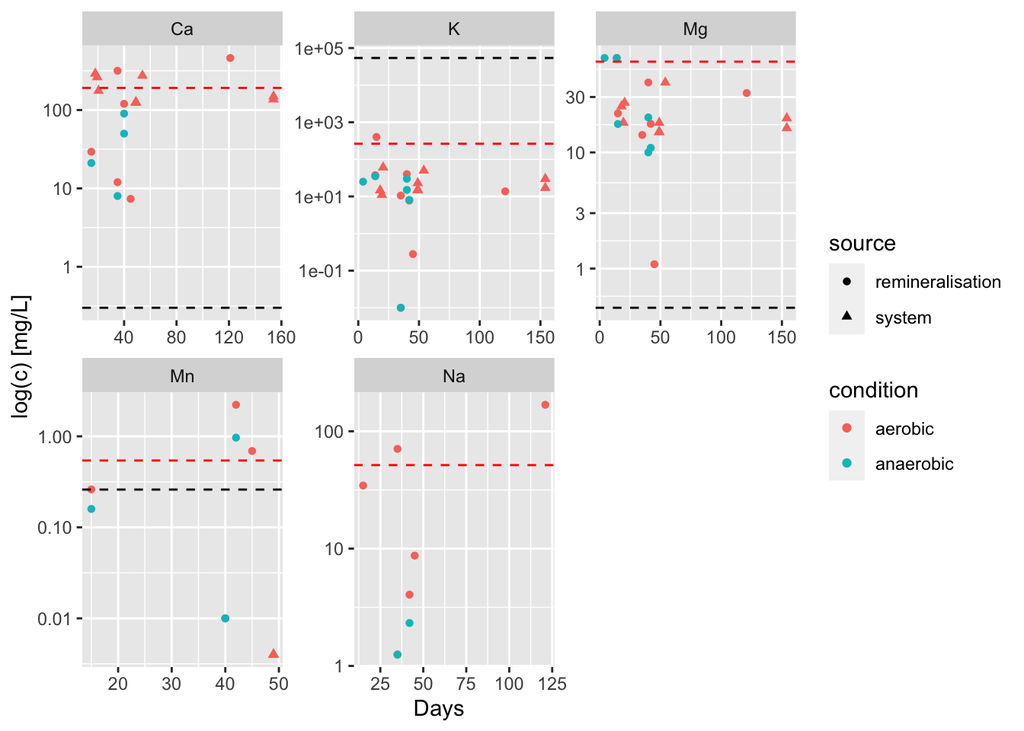

```r
plotlevels <- unlist(unique(subset(plotdata, group1 == 3, select = nutrient)))

plotdata %>%
  filter(group1 == 3) %>%
  ggplot(aes(x = days, y = concentration, colour = condition, shape = source)) +
  geom_point() +
  geom_hline(data = lowSolubility[which(lowSolubility$nutrient %in% plotlevels),], aes(yintercept = minSolubility), linetype = 'dashed') +
  geom_hline(data = targetConc[which(targetConc$nutrient %in% plotlevels),], aes(yintercept = mean), linetype = 'dashed', color = 'red') +
  facet_wrap(facets = vars(as.factor(nutrient)), scales = 'free') +
  scale_y_log10() +
  labs(
    x = 'Days',
    y = 'log(c) [mg/L]'
    )
```

### Group 4

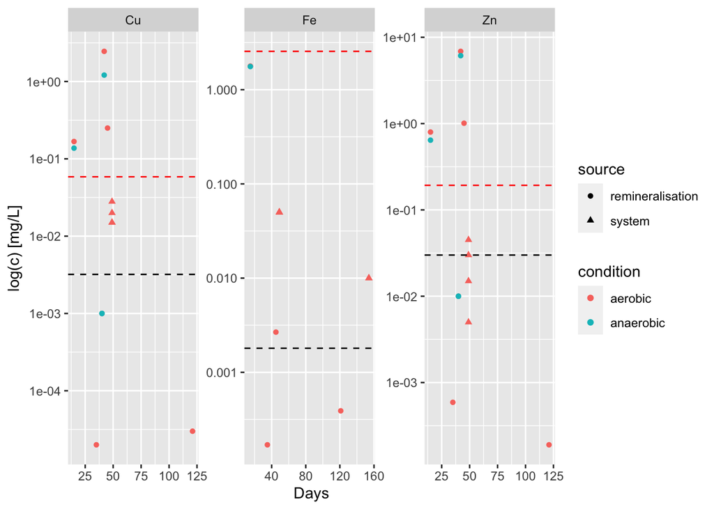

```r
plotlevels <- unlist(unique(subset(plotdata, group1 == 4, select = nutrient)))

plotdata %>%
  filter(group1 == 4) %>%
  ggplot(aes(x = days, y = concentration, colour = condition, shape = source)) +
  geom_point() +
  geom_hline(data = lowSolubility[which(lowSolubility$nutrient %in% plotlevels),], aes(yintercept = minSolubility), linetype = 'dashed') +
  geom_hline(data = targetConc[which(targetConc$nutrient %in% plotlevels),], aes(yintercept = mean), linetype = 'dashed', color = 'red') +
  facet_wrap(facets = vars(as.factor(nutrient)), scales = 'free') +
  scale_y_log10() +
  labs(
    x = 'Days',
    y = 'log(c) [mg/L]'
    )
```

### Nonmetals

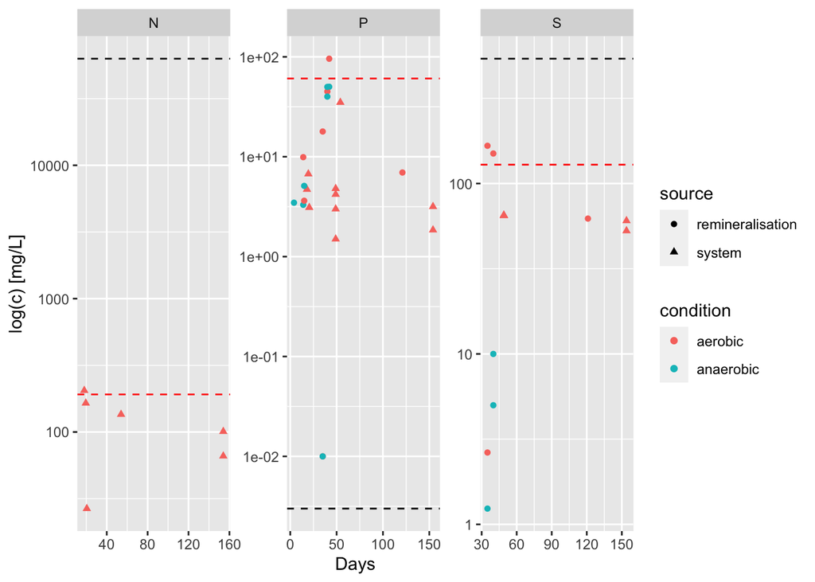

```r
plotlevels <- unlist(unique(subset(plotdata, group2 == 'nonmetal', select = nutrient)))

plotdata %>%
  filter(group2 == 'nonmetal') %>%
  ggplot(aes(x = days, y = concentration, colour = condition, shape = source)) +
  geom_point() +
  geom_hline(data = lowSolubility[which(lowSolubility$nutrient %in% plotlevels),], aes(yintercept = minSolubility), linetype = 'dashed') +
  geom_hline(data = targetConc[which(targetConc$nutrient %in% plotlevels),], aes(yintercept = mean), linetype = 'dashed', color = 'red') +
  facet_wrap(facets = vars(as.factor(nutrient)), scales = 'free') +
  scale_y_log10() +
  labs(
    x = 'Days',
    y = 'log(c) [mg/L]'
    )
```

### Alkaline metals

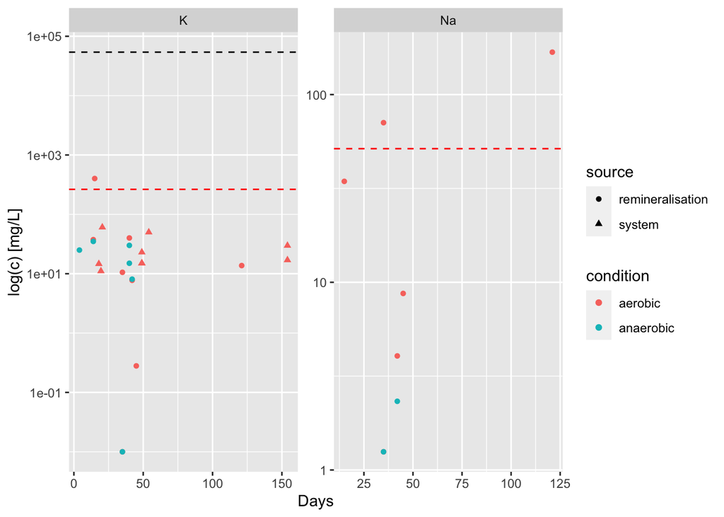

```r
plotlevels <- unlist(unique(subset(plotdata, group2 == 'alkaline metal', select = nutrient)))

plotdata %>%
  filter(group2 == 'alkaline metal') %>%
  ggplot(aes(x = days, y = concentration, colour = condition, shape = source)) +
  geom_point() +
  geom_hline(data = lowSolubility[which(lowSolubility$nutrient %in% plotlevels),], aes(yintercept = minSolubility), linetype = 'dashed') +
  geom_hline(data = targetConc[which(targetConc$nutrient %in% plotlevels),], aes(yintercept = mean), linetype = 'dashed', color = 'red') +
  facet_wrap(facets = vars(as.factor(nutrient)), scales = 'free') +
  scale_y_log10() +
  labs(
    x = 'Days',
    y = 'log(c) [mg/L]'
    )
```

### Alkaline earth metals

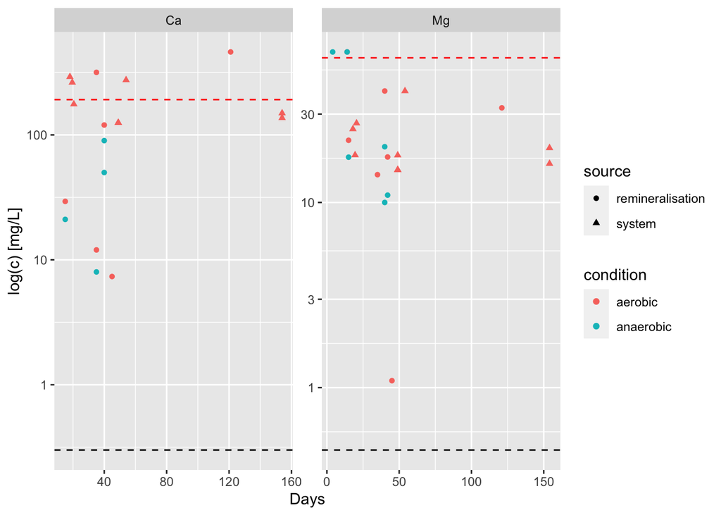

```r
plotlevels <- unlist(unique(subset(plotdata, group2 == 'alkaline earth metal', select = nutrient)))

plotdata %>%
  filter(group2 == 'alkaline earth metal') %>%
  ggplot(aes(x = days, y = concentration, colour = condition, shape = source)) +
  geom_point() +
  geom_hline(data = lowSolubility[which(lowSolubility$nutrient %in% plotlevels),], aes(yintercept = minSolubility), linetype = 'dashed') +
  geom_hline(data = targetConc[which(targetConc$nutrient %in% plotlevels),], aes(yintercept = mean), linetype = 'dashed', color = 'red') +
  facet_wrap(facets = vars(as.factor(nutrient)), scales = 'free') +
  scale_y_log10() +
  labs(
    x = 'Days',
    y = 'log(c) [mg/L]'
    )
```

### Metalloids

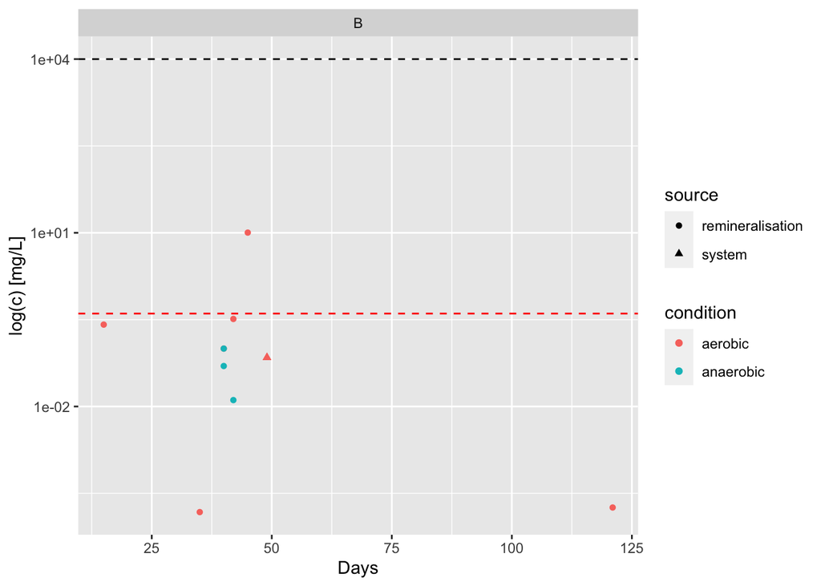

```r
plotlevels <- unlist(unique(subset(plotdata, group2 == 'metalloid', select = nutrient)))

plotdata %>%
  filter(group2 == 'metalloid') %>%
  ggplot(aes(x = days, y = concentration, colour = condition, shape = source)) +
  geom_point() +
  geom_hline(data = lowSolubility[which(lowSolubility$nutrient %in% plotlevels),], aes(yintercept = minSolubility), linetype = 'dashed') +
  geom_hline(data = targetConc[which(targetConc$nutrient %in% plotlevels),], aes(yintercept = mean), linetype = 'dashed', color = 'red') +
  facet_wrap(facets = vars(as.factor(nutrient)), scales = 'free') +
  scale_y_log10() +
  labs(
    x = 'Days',
    y = 'log(c) [mg/L]'
    )
```

### Transition metals

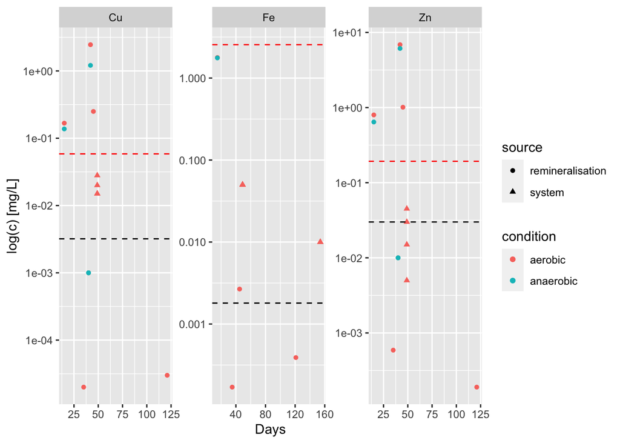

```r
plotlevels <- unlist(unique(subset(plotdata, group2 == 'transition metal', select = nutrient)))

plotdata %>%
  filter(group2 == 'transition metal') %>%
  ggplot(aes(x = days, y = concentration, colour = condition, shape = source)) +
  geom_point() +
  geom_hline(data = lowSolubility[which(lowSolubility$nutrient %in% plotlevels),], aes(yintercept = minSolubility), linetype = 'dashed') +
  geom_hline(data = targetConc[which(targetConc$nutrient %in% plotlevels),], aes(yintercept = mean), linetype = 'dashed', color = 'red') +
  facet_wrap(facets = vars(as.factor(nutrient)), scales = 'free') +
  scale_y_log10() +
  labs(
    x = 'Days',
    y = 'log(c) [mg/L]'
    )
```